Skip to main content

# Ride Knox 2026 Annual Report — Built by the System

Author

Zaharia Selman

*Reader note: this document is written for the General Manager and the board. Code is hidden throughout; every number in the prose is computed by the document from the pipeline’s extracts at render time.*

## 1. What this system holds, and what it covers

Across every source file the pipeline was presented with **515,536 raw rows**; **485,540** loaded, **29,996** excluded under named reasons, and the arithmetic closes file by file (ledger below). **481,770** trips meet the reporting standard. 2026 coverage ends **October 11, 2026**.

The October 2026 delivery was released from the initial pipeline quarantine because of the data-team’s exception. The pipeline excluded one malformed row and reports trips only up until October 11, 2026. October figures will therefore only show partial-month analyses.

System reconciliation ledger: every raw row of every source file, attributed to exactly one outcome.

| file | raw_rows | loaded | exclusion | excluded_rows | notes |
| --- | --- | --- | --- | --- | --- |
| weather_knoxville_daily.csv | 698 | 695 | duplicate_date_rows | 3 | 6 precip sentinels -> NULL (rows kept) |
| trips_2025.csv | 250600 | 249737 | dropped_structural | 0 | dominant month 2025-06 |
| trips_2025.csv | NA | NA | duplicate_copies_in_file | 600 | NA |
| trips_2025.csv | NA | NA | already_loaded_overlap | 0 | NA |
| trips_2025.csv | NA | NA | unknown_station | 263 | NA |
| trips_2026_h1.csv | 137341 | 136991 | dropped_structural | 0 | dominant month 2026-06 |
| trips_2026_h1.csv | NA | NA | duplicate_copies_in_file | 350 | NA |
| trips_2026_h1.csv | NA | NA | already_loaded_overlap | 0 | NA |
| trips_2026_h1.csv | NA | NA | unknown_station | 0 | NA |
| trips_2026_07.csv | 33085 | 32785 | dropped_structural | 0 | dominant month 2026-07 |
| trips_2026_07.csv | NA | NA | duplicate_copies_in_file | 120 | NA |
| trips_2026_07.csv | NA | NA | already_loaded_overlap | 180 | NA |
| trips_2026_07.csv | NA | NA | unknown_station | 0 | NA |
| trips_2026_08.csv | 30045 | 29765 | dropped_structural | 0 | dominant month 2026-08 |
| trips_2026_08.csv | NA | NA | duplicate_copies_in_file | 120 | NA |
| trips_2026_08.csv | NA | NA | already_loaded_overlap | 160 | NA |
| trips_2026_08.csv | NA | NA | unknown_station | 0 | NA |
| trips_2026_09_resend.csv | 27760 | 27500 | dropped_structural | 0 | dominant month 2026-09 |
| trips_2026_09_resend.csv | NA | NA | duplicate_copies_in_file | 110 | NA |
| trips_2026_09_resend.csv | NA | NA | already_loaded_overlap | 150 | NA |
| trips_2026_09_resend.csv | NA | NA | unknown_station | 0 | NA |
| trips_2026_10.csv | 8247 | 8067 | dropped_structural | 1 | dominant month 2026-10 |
| trips_2026_10.csv | NA | NA | duplicate_copies_in_file | 39 | NA |
| trips_2026_10.csv | NA | NA | already_loaded_overlap | 140 | NA |
| trips_2026_10.csv | NA | NA | unknown_station | 0 | NA |
| trips_2026_09.csv | 27760 | 0 | quarantined_whole_file_header-mismatch | 27760 | never loaded; see gate receipts |

## 2. The two-year picture

```
# A tibble: 1 × 1
  total_trips
        <dbl>
1      233803
```

## 3. The Integration Question

Daily trip and weather integration audit

| Integration audit check | Result |
| --- | --- |
| Daily trip records before weather join | 568 |
| Daily trip records after weather join | 568 |
| Unique daily dates after join | 568 |
| 2025 daily records | 284 |
| 2026 daily records | 284 |
| Dates without a matching weather record | 0 |
| Matched dates with missing precipitation | 6 |

The weather join preserved all `568` daily trip records, confirming that the join did not change the number of observations. The comparison includes `284` days from each year, covering the same January 1–October 11 dates chosen as the acceptable comparison window. All trip dates had a corresponding weather record. However, precipitation was missing for `6` matched dates because sentinel values had been converted to missing values during warehouse loading. These observations will be excluded from analyses requiring precipitation rather than treating missing values as zero. Lastly, in the following analyses, day pass riders are counted as non-members to ensure there are two categories (members and non-members (casual and day pass riders)).

Comparison of the 2026 year effect before and after weather/calendar adjustment

| Model | 2026 year effect (trips/day) | 95% CI lower | 95% CI upper | p-value |
| --- | --- | --- | --- | --- |
| Naive | 30.69 | 9.77 | 51.62 | 0 |
| Weather-adjusted | 40.48 | 30.96 | 50.00 | 0 |

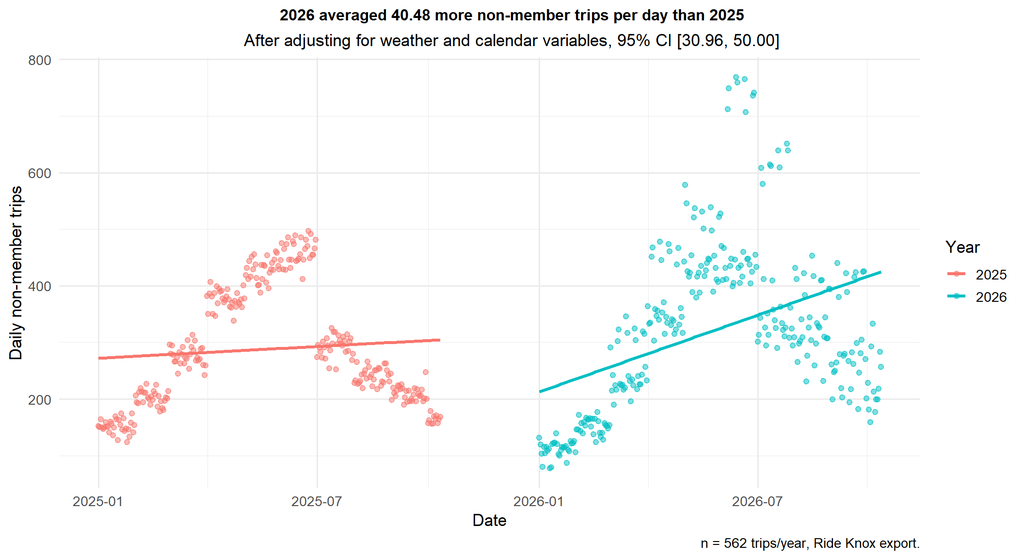

Daily non-member trips during the comparable January 1–October 11 periods in 2025 and 2026. Lines show separate linear trends for each year.

### Integration Question Interpretation

For the model analyses, 2025 includes casual riders only as non-member riders, while 2026 bundles casual and day pass riders as non-member riders. The naive model estimates that 2026 averaged 30.69 more non-member trips per day than 2025 (95% CI [9.77 – 51.62]). After adjusting for maximum temperature, minimum temperature, precipitation, weekday, and month, the estimated average difference increased to 40.48 more non-member trips per day between 2025 and 2026 (95% CI [30.96 – 50]; see figs/integration_daily_trips.png). The larger adjusted estimate/model suggests that weather and calendar structures account for **some** variation in daily non-member trips across years, information not available in the naive model. However, these adjustments do not establish the cause of that increase from the naive model.

## 4. Capacity, with each year’s own denominators

Capacity changes and station activity for stations leadership acted on, 2025–2026

| Station ID | Station Name | 2025 departures | 2026 departures | 2025 docks | 2026 docks | 2025 departures/dock | 2026 departures/dock |
| --- | --- | --- | --- | --- | --- | --- | --- |
| S06 | Hodges Library | 25882 | 22472 | 24 | 32 | 1078.4 | 702.3 |
| S08 | Student Union - UT | 24780 | 21402 | 24 | 32 | 1032.5 | 668.8 |
| S25 | Cumberland Ave & 22nd St | NA | 14606 | NA | 16 | NA | 912.9 |

The capacity comparison highlights leadership acted on two stations (Hodges Library (S06) and Student Union - UT (S08)) by increasing the dock capacity from 24 in 2025 to 32 in 2026. Cumberland Ave & 22nd St (S25) was a new station added in 2026 so that is why it has no 2025 comparison.

Departures per dock are calculated using each year’s actual dock count (as calculated by the `dock_history` table in the `sql/schema.sql`), therefore historical dock counts are appropriately used for 2025’s capacity. This provides a year-correct measure of station activity relative to available capacity. Although departures per dock help describe station pressure, they do not independently establish whether a station experienced capacity shortages or unmet demand.

## 5. Memo to the General Manager

**Evidence**

For the analyses, 2025 includes casual riders only as non-member riders, while 2026 bundles casual and day pass riders as non-member riders. To make the year over year comparisons comparable, analyses were conducted between January 1 - October 11 of 2025 and 2026 since this is the extent to the data from 2026.

*Without* controlling for weather and calendar structure, 2026 averaged 30.69 more non-member trips per day than 2025 (95% CI [9.77 – 51.62]). After adjusting for maximum temperature, minimum temperature, precipitation, weekday, and month, the estimated average difference increased to 40.48 more non-member trips per day between 2025 and 2026 (95% CI [30.96 – 50]; see figs/integration_daily_trips.png).

The new Ride Knox employee and/or auditors can get everything from the analyses to the results from one command.

**Interpretation**

This one system accommodates the successor coming in January, vendor contract renewal, and the auditors that want to know how our published numbers are produced.

**Limitations**

The one minute cutoff rule implemented in the analysis causes us to lose data points that may otherwise influence our analysis. We excluded trips longer than 24 hours (bikes likely never docked properly). S99 stations have been filtered out, but trips missing an end_station_id have been kept in for these analyses. We must use a comparable window because we don’t have data past October 11, 2026. There are stations that have been excluded because they were missing both end station IDs and end times. We don’t currently have information from our riders that could be influencing their riding (e.g., reasons for riding, etc.) other than weather and calendar structure. Other than the test stations (S99) that should not be included in any analyses, the other options were chosen to best represent valid trips, while not losing trips that may have operational problems that can be investigated by the op’s team at a later time.

**Recommendation**

We should consider collecting survey data from riders to include as variables other than weather and calendar structure. This handover can now be used and updated with every new vendor export.